# Data objects, and class types, and more. Oh my!

Kate Nelson

1/17/2020

## Objectives

- Learn about the structure of different data types in R
- Learn how to subset your data using base R
- Begin to describe and summarize your data

## Before Lab

- Read Chapters 4 through 8 (except for the last section of each chapter) of [YaRrr! The Pirate’s Guide to R](https://bookdown.org/ndphillips/YaRrr/basics.html)

## Before Next Class

- Read Chapters 3.1 to 3.4, 3.6, and Chapter 5 of [R for Data Science](https://r4ds.had.co.nz/data-visualisation.html)
- Complete the Lab-3-Tutorial found in Canvas. This tutorial will introduce you to the `dplyr` and `ggplot2` pacakges using the same dataset we will explore in this tutorial.

## Acknowledgements

Much of this material is adapted from Dr. Emily Burchfield’s fantastic tutorial on [Data Management](https://eburchfield.github.io/files/2_describing_data_lab.html).

### Set-up

First, let’s install the `gapminder` package, type `install.packages("gapminder")` in the console to pull the package off of the `CRAN` repository onto your computer. The package documentation can be found [here](https://cran.r-project.org/web/packages/gapminder/index.html) and more information about the Gapminder project can be found at www.gapminder.org.

Then load the package and the gapminder data.

```r
library(gapminder)
data(gapminder)
```

Remember that `library()` loads the package for us in your current R session and `data()` pulls the pre-made `gapminder` dataset into your Global Environment.

### The Data Structure

Let’s inspect the new `gapminder` dataset:

```r
head(gapminder)
```

```
## # A tibble: 6 x 6
##   country     continent  year lifeExp      pop gdpPercap
##   <fct>       <fct>     <int>   <dbl>    <int>     <dbl>
## 1 Afghanistan Asia       1952    28.8  8425333      779.
## 2 Afghanistan Asia       1957    30.3  9240934      821.
## 3 Afghanistan Asia       1962    32.0 10267083      853.
## 4 Afghanistan Asia       1967    34.0 11537966      836.
## 5 Afghanistan Asia       1972    36.1 13079460      740.
## 6 Afghanistan Asia       1977    38.4 14880372      786.
```

Our `gapminder` dataset includes the following variables:

- country
- continent
- year
- lifeExp or life expectancy
- pop or population
- gdpPercap or Gross Domestic Product (GDP) per capita

Before we start working with our data it is helpful to understand its data structure. What type of data object is this? It looks like a table, right? Let’s see what R says it is by using `class()`.

```r
class(gapminder)
```

```
## [1] "tbl_df"     "tbl"        "data.frame"
```

Notice that our R output says we have classes ‘tbl_df’, ‘tbl’ and ‘data.frame’. This is saying the class of the data object is a table and/or data frame. If you check your environment window you’ll notice that under the “Type” column you have `tbl_df`.

OK, but what if I’d like to know what `class` each variable is? (For example: Are Country’s listed as character strings or a factor/level?)

Using Base R functionality we can use a `$` to access specific named columns in a dataframe or table. So we can access the Country column by typing `` `gapminder$Country` ``. Try checking the class of the Country column.

```r
class(gapminder$country)
```

```
## [1] "factor"
```

So the country column uses a `Factor` data class.

That means each country name is instead treated as a unique value or level (treated as nominal/categorical data that takes on a number of limited possible values). More information about using factors can be found [here](http://monashbioinformaticsplatform.github.io/2015-09-28-rbioinformatics-intro-r/01-supp-factors.html). Understanding factors can be important for some modeling where categorical or ordered variables are used. On a practical level this will become very useful as we start to group data using the `dplyr` package. More fundamentally it is good to be aware of factors because if your numerical variables are in a factor class operations on those variables will not work as intended. Indeed, transformation from factor to numerical data classes is not entirely straightforward. Converting directly from a factor to a numeric data class will not report any errors, but will not provide the expected result. Instead you must convert from factor to character class and then convert from character to a numeric. One way to do this is by typing `as.numeric(as.character("your data"))`.

Our *categorical* variables, or variables that take on a number of limited possible values, are coded as `“factor”` variables.

Now if we want to check the class for each column we could repreat this for each variable by typing `class(gapminder$variable_name)`, or we could use the `sapply()` function to apply the `class` function across all variables in the `gapminder` dataset. Remember, if you’re unfamiliar with any function, i.e. `sapply()`, you can ask `R` how it works using `?sapply()`.

```r
?sapply()
```

```
## starting httpd help server ... done
```

```r
sapply(gapminder, class)
```

```
##   country continent      year   lifeExp       pop gdpPercap
##  "factor"  "factor" "integer" "numeric" "integer" "numeric"
```

Now we see that the year column is stored as integers, the lifeExp column is stored as numeric, etc….

There is another function for investigating data structure is we can use that will actually tell us about the data type of the entire object and the data class of each column. Try using the `str()` function.

```r
str(gapminder)
```

```
## Classes 'tbl_df', 'tbl' and 'data.frame':    1704 obs. of  6 variables:
##  $ country  : Factor w/ 142 levels "Afghanistan",..: 1 1 1 1 1 1 1 1 1 1 ...
##  $ continent: Factor w/ 5 levels "Africa","Americas",..: 3 3 3 3 3 3 3 3 3 3 ...
##  $ year     : int  1952 1957 1962 1967 1972 1977 1982 1987 1992 1997 ...
##  $ lifeExp  : num  28.8 30.3 32 34 36.1 ...
##  $ pop      : int  8425333 9240934 10267083 11537966 13079460 14880372 12881816 13867957 16317921 22227415 ...
##  $ gdpPercap: num  779 821 853 836 740 ...
```

Notice how each column is reported with a `$`? We’ll use this notation to access specific columns in our dataset.

As shown above, we can extract information for each variable in the dataset using `$`. For example, if we wanted to determine the range of years in the dataset we can simply type:

```r
range(gapminder$year)
```

```
## [1] 1952 2007
```

So the data runs from 1952 to 2007. Is there data for every year over this period?

```r
unique(gapminder$year)
```

```
##  [1] 1952 1957 1962 1967 1972 1977 1982 1987 1992 1997 2002 2007
```

Good to know. Looks like this dataset only has observations every five years.

### Indexing

I’ll refer to base R a lot in this class. When I say this, I’m referring to the functions that come in the basic R language and that are not associated with a particular package. The functions we’ve used so far like `head()` and `unique()` are base `R` functions. Next week, we’ll start working with functions from the `dplyr` package that do *not* come from base `R` including `select()`, `filter()` and `arrange()`. In general in this class, when I refer to packages, I will just list the package name in `this font.` For example, I may refer to `ggplot2`, `dplyr`, or `gapminder`. I will refer to functions by including closed parentheses `()`, i.e. `select()`, `filter()`, etc. This is a reminder that functions almost always include *agruments* which you have to include, i.e. `mean(x)` tells `R` to compute the mean of the variable `x`. Ok, now that we’re up to speed on notation and terms, let’s start playing with our data.

Let’s start by seeing what would happen if we used `str()` on a vector instead of a data frame. First store one variable from `gapminder` to a new object then check its structure.

```r
v<-gapminder$lifeExp

str(v)
```

```
##  num [1:1704] 28.8 30.3 32 34 36.1 ...
```

You should see a single data class name (e.g. “num” for numeric) followed by `[1:1704]`. The brackets denote indexing. Here, becuase we have a single vector and we are reporting the entire vector we see `1:1704`. This is basically saying that we are looking at the 1st through the 1704th items in the vector (which is all items in the vector). Not sure about this? You can double-check the number of records in this vector using `length()`.

Now let’s try indexing on a data frame instead of a vector. With the vector within the `[]` we had one range, for a dataframe we will have two ranges: `[x,y]`. In this case we have indexing for our **rows/records** in the x slot and indexing for our **columns/variables** in the y slot. (Some functions wil include an argument asking along which dimension you would like to calculate something. In this case **x** is the **1st** dimension and **y** is the **2nd** dimension.)

Let’s say you want to extract observations for the country of Sri Lanka. We can use base R to index the full dataset to create a smaller dataset:

```r
sri_lanka <- gapminder[gapminder$country == "Sri Lanka", ]
head(sri_lanka)
```

```
## # A tibble: 6 x 6
##   country   continent  year lifeExp      pop gdpPercap
##   <fct>     <fct>     <int>   <dbl>    <int>     <dbl>
## 1 Sri Lanka Asia       1952    57.6  7982342     1084.
## 2 Sri Lanka Asia       1957    61.5  9128546     1073.
## 3 Sri Lanka Asia       1962    62.2 10421936     1074.
## 4 Sri Lanka Asia       1967    64.3 11737396     1136.
## 5 Sri Lanka Asia       1972    65.0 13016733     1213.
## 6 Sri Lanka Asia       1977    65.9 14116836     1349.
```

Don’t forget the `,` after `“Sri Lanka”`! This tells R that you want to find ALL **rows** (first item) in which `country == “Sri Lanka”` and to include ALL **columns** (second item) in the dataset. (So leaving an item empty defaults to include all.) If you only wanted the first column, the you could type `gapminder[gapminder$country == “Sri Lanka”, 1]`. So we can subset using either column or row number/index or column or row value.

Note that in R, `=`is equivalent to `<-` and is used for assignment, i.e. to create a variable such as `x = 5` or preferably `x <-5`. On the other hand, `==` is used for equality testing, i.e. if we want to confirm that the variable `x` we just created is, in fact, equal to 5, we could type `x==5`. The console should return `TRUE`. Try it!

Back to the indexing. If we didn’t want ALL of the columns and only wanted the variable `gdpPercap` for Sri Lanka, we could do the following:

```r
sri_lanka_gdp <- gapminder[gapminder$country == "Sri Lanka", "gdpPercap"]
head(sri_lanka_gdp)
```

```
## # A tibble: 6 x 1
##   gdpPercap
##       <dbl>
## 1     1084.
## 2     1073.
## 3     1074.
## 4     1136.
## 5     1213.
## 6     1349.
```

```r
sri_lanka_gdp <- gapminder[gapminder$country == "Sri Lanka", c("year", "gdpPercap")]
head(sri_lanka_gdp)
```

```
## # A tibble: 6 x 2
##    year gdpPercap
##   <int>     <dbl>
## 1  1952     1084.
## 2  1957     1073.
## 3  1962     1074.
## 4  1967     1136.
## 5  1972     1213.
## 6  1977     1349.
```

Here we create a list of column names we want to pull out of the dataset using `c()` which combines values into a vector or list much like we did last week. Note that you can use either a list of column names or a list of numerical indexes (e.g. Use c(1,3,5) to select the first, third, and fifth columns, or use c(1:5) to select columns one through five).

Now let’s see if you can calculate the average, maximum, and minimum GDP per capita for Sri Lanka over the last 50 years.

```r
mean(sri_lanka_gdp$gdpPercap, na.rm=TRUE)
```

```
## [1] 1854.731
```

```r
max(sri_lanka_gdp$gdpPercap, na.rm=TRUE)
```

```
## [1] 3970.095
```

```r
min(sri_lanka_gdp$gdpPercap, na.rm=TRUE)
```

```
## [1] 1072.547
```

```r
range(sri_lanka_gdp$gdpPercap, na.rm=TRUE) # this will give us both the min and max
```

```
## [1] 1072.547 3970.095
```

Ok, what if I want to know the average GDP per capita for all countries or for all years? `aggregate()` can help with that. If you’re confused check out the `aggregate()` help info by typing `?aggregate()` into your console.

```r
t<-aggregate(gapminder[ ,"gdpPercap"], by= gapminder["country"], FUN=mean, na.action=rm)
head(t)
```

```
##       country  gdpPercap
## 1 Afghanistan   802.6746
## 2     Albania  3255.3666
## 3     Algeria  4426.0260
## 4      Angola  3607.1005
## 5   Argentina  8955.5538
## 6   Australia 19980.5956
```

```r
t2<-aggregate(gapminder[ ,"gdpPercap"], by= gapminder["year"], FUN=mean, na.action=rm)
head(t2)
```

```
##   year gdpPercap
## 1 1952  3725.276
## 2 1957  4299.408
## 3 1962  4725.812
## 4 1967  5483.653
## 5 1972  6770.083
## 6 1977  7313.166
```

Want to see how countries rank by GDP? Let’s try `order()` for our dataframe.(Use `sort()` for vectors.)

```r
t<-t[order(t$gdpPercap),]
head(t)
```

```
##       country gdpPercap
## 88    Myanmar  439.3333
## 18    Burundi  471.6630
## 43   Ethiopia  509.1152
## 42    Eritrea  541.0025
## 87 Mozambique  542.2783
## 78     Malawi  575.4472
```

This lists the countries by GDP in ascending order. What about descending order?

```r
t<-t[order(-t$gdpPercap),] # or we can use t[order(t$gdpPercap, decreasing=TRUE),]
head(t)
```

```
##           country gdpPercap
## 72         Kuwait  65332.91
## 124   Switzerland  27074.33
## 96         Norway  26747.31
## 135 United States  26261.15
## 21         Canada  22410.75
## 91    Netherlands  21748.85
```

What if we want to add a new variable to our dataset, say an indicator of whether or not a country is located in the continent Africa. We can add a named column to our `data.frame` using the `$` and `<-` operators .

```r
africa<- gapminder #assign the original gapminder dataset to a new object for further manipulation

africa$africa <- ifelse(gapminder$continent == "Africa", 1, 0)

head(africa)
```

```
## # A tibble: 6 x 7
##   country     continent  year lifeExp      pop gdpPercap africa
##   <fct>       <fct>     <int>   <dbl>    <int>     <dbl>  <dbl>
## 1 Afghanistan Asia       1952    28.8  8425333      779.      0
## 2 Afghanistan Asia       1957    30.3  9240934      821.      0
## 3 Afghanistan Asia       1962    32.0 10267083      853.      0
## 4 Afghanistan Asia       1967    34.0 11537966      836.      0
## 5 Afghanistan Asia       1972    36.1 13079460      740.      0
## 6 Afghanistan Asia       1977    38.4 14880372      786.      0
```

```r
head(africa[africa$africa==1,]) #confirm that locations with continent == Africa have an africa value of 1
```

```
## # A tibble: 6 x 7
##   country continent  year lifeExp      pop gdpPercap africa
##   <fct>   <fct>     <int>   <dbl>    <int>     <dbl>  <dbl>
## 1 Algeria Africa     1952    43.1  9279525     2449.      1
## 2 Algeria Africa     1957    45.7 10270856     3014.      1
## 3 Algeria Africa     1962    48.3 11000948     2551.      1
## 4 Algeria Africa     1967    51.4 12760499     3247.      1
## 5 Algeria Africa     1972    54.5 14760787     4183.      1
## 6 Algeria Africa     1977    58.0 17152804     4910.      1
```

```r
#And another way to do this
africa$africa2<-0

africa$africa2[africa$continent == "Africa"] <- 1
```

We’ve now covered some of the basics of indexing and subsetting. I recommend these tutorials on [data subsetting](http://swcarpentry.github.io/r-novice-gapminder/06-data-subsetting/) and [data manipulation](http://swcarpentry.github.io/r-novice-gapminder/05-data-structures-part2/) to help solidfy and extend your understanding. We will introduce data manipulation using `dplyr` next week, but will still make use of base R frequently.

Make sure you’re familiar with how to index and wrangle data in base R before we proceed!

### Visualizing our data

For now we’ll take a look at using base R `plot()` and `hist()`. Next week we’ll start using `ggplot` to make figures.

Let’s start with the quickest and simplest overall visualization of the entire `gapminder` dataset.

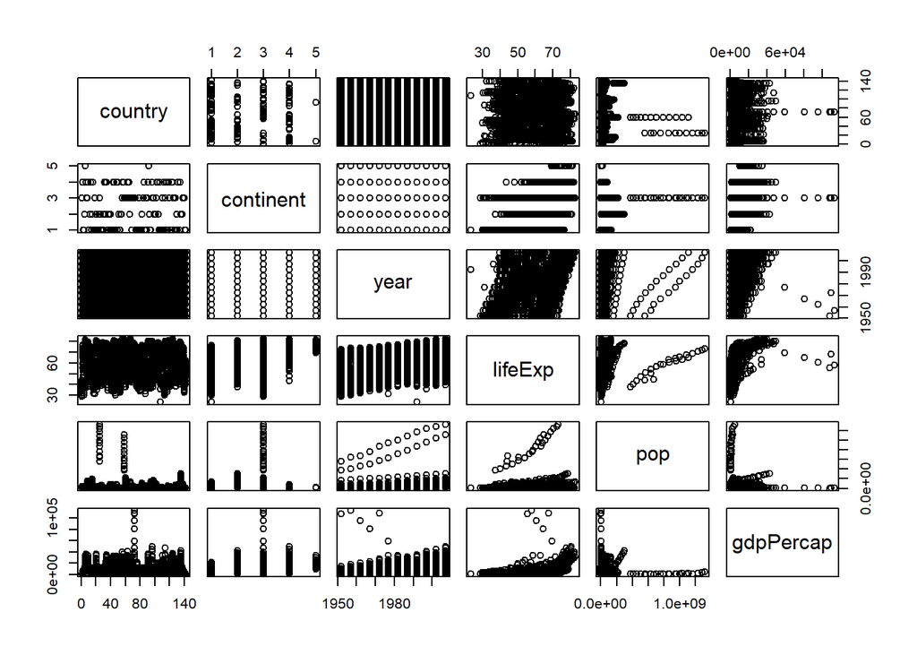

```r
plot(gapminder)
```

This produces a matrix of scatterplots where one variable is along the **y-axis** and another is along the **x-axis**. Recall that some of our variables are `factor` class (or categorical data). Plotting them along x-y axes doesn’t really make much sense. Let’s try plotting this again, but only for the numeric variables by subsetting within `plot()`.

```r
# manually specify --> totally fine for small datasets, not so great when you have many variables or for scaling up/automating
  classes<-sapply(gapminder, class)
  classes
```

```
##   country continent      year   lifeExp       pop gdpPercap
##  "factor"  "factor" "integer" "numeric" "integer" "numeric"
```

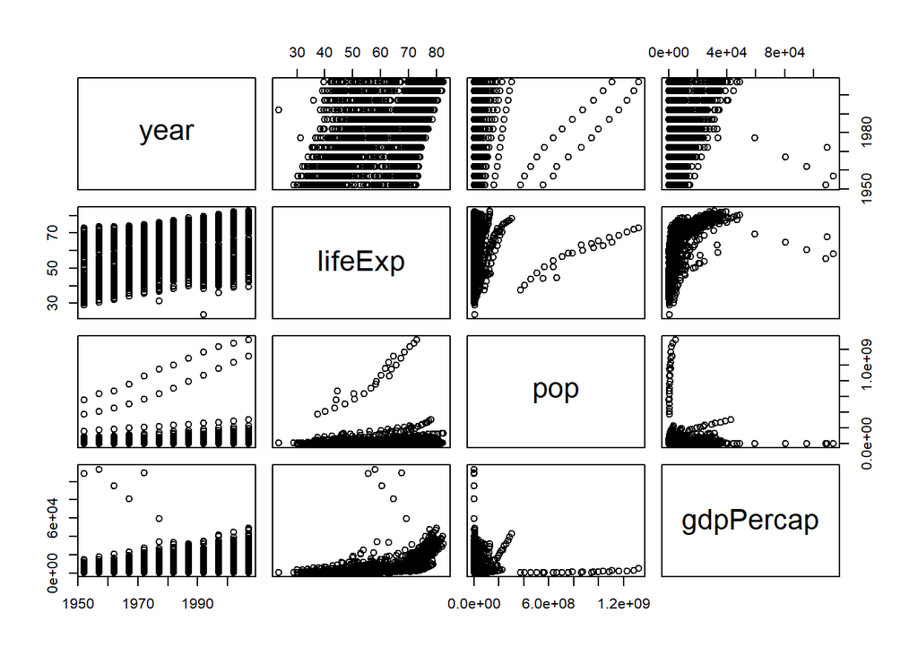

```r
  plot(gapminder[,c("year","lifeExp","pop","gdpPercap")])
  plot(gapminder[,c(3,4,5,6)])
```

```r
# one way to do this without manually specifying
  isnum<-classes[classes != "factor"] #subset of classes vector with only columns that are not factors
  isnum
```

```
##      year   lifeExp       pop gdpPercap
## "integer" "numeric" "integer" "numeric"
```

```r
  plot(gapminder[ , names(gapminder) %in% names(isnum)]) #plot for the subset where column names in gapminder match the column names in the isnum vector

# another way to subset and plot using the which function
  isnum_col<-which(classes != "factor") #return a vector of the indices where class is not factor

  isnum_col<-which(sapply(gapminder, class) != "factor") #same as above, but we use only 1 line instead of 2


  plot(gapminder[,isnum_col]) #plot for the subset of gapminder where column indices are in isnum_col

  plot(gapminder[ ,which(sapply(gapminder, class) != "factor")]) #plot for the subset of gapminder where column indices are in isnum_col
```

As you can see there are lots of potential ways to do this. Many more than I will show here. Some require fewer lines, some are cleaner than others, some require more manual manipulation. How you do this is up to you, but I have a couple of general reccomendations/observations:

1. Don’t spend hours trying to create a one-line solution when you can spend 5 minutes on a three-line solution.
2. Simpler is usually better.
3. If it’s hard to read, it’s hard to troubleshoot.
4. Comment, comment, comment.

What if I wanted to change the color or shape of the points?

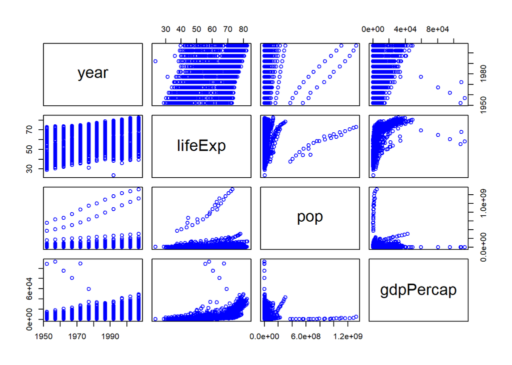

```r
plot(gapminder[,c(3,4,5,6)], col="blue")
```

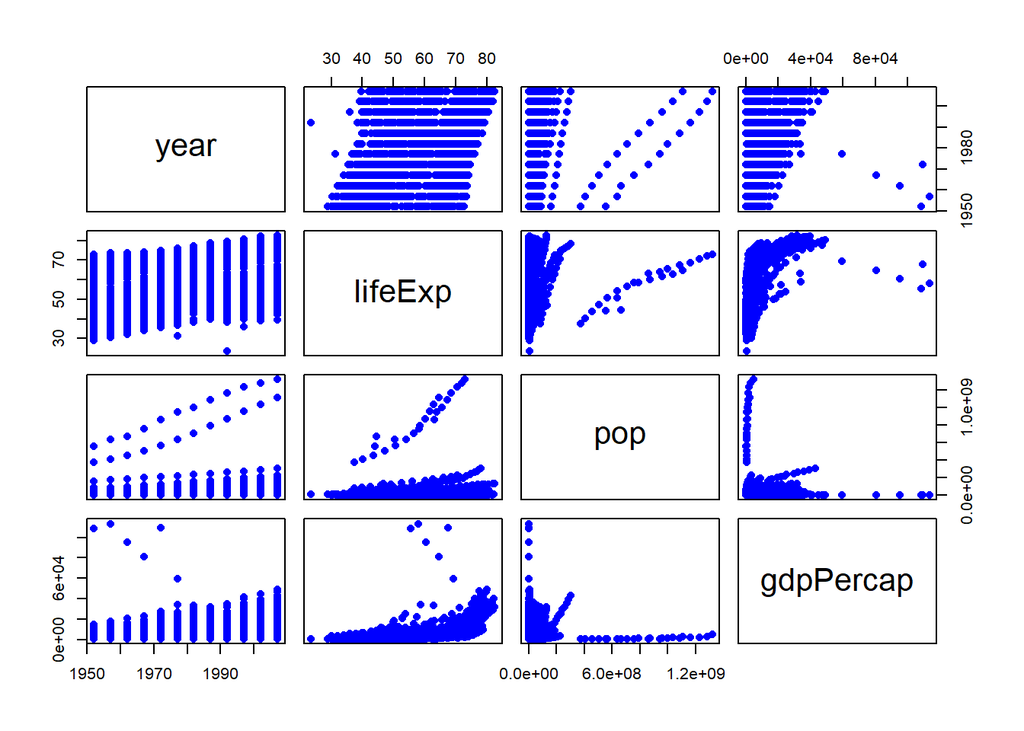

```r
plot(gapminder[,c(3,4,5,6)], col="blue", pch=16)
```

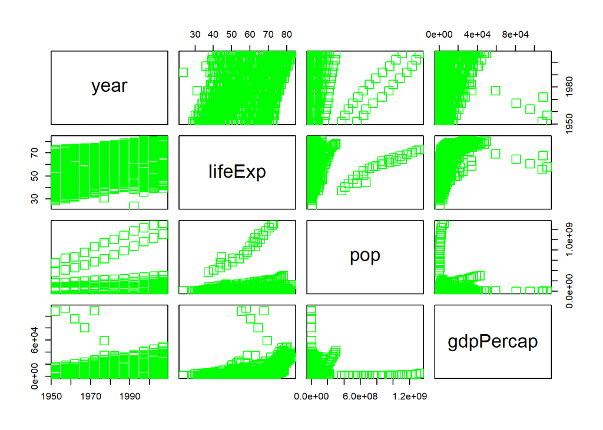

```r
plot(gapminder[,c(3,4,5,6)], col="green", pch=0, cex=2) #cex changes the size
```

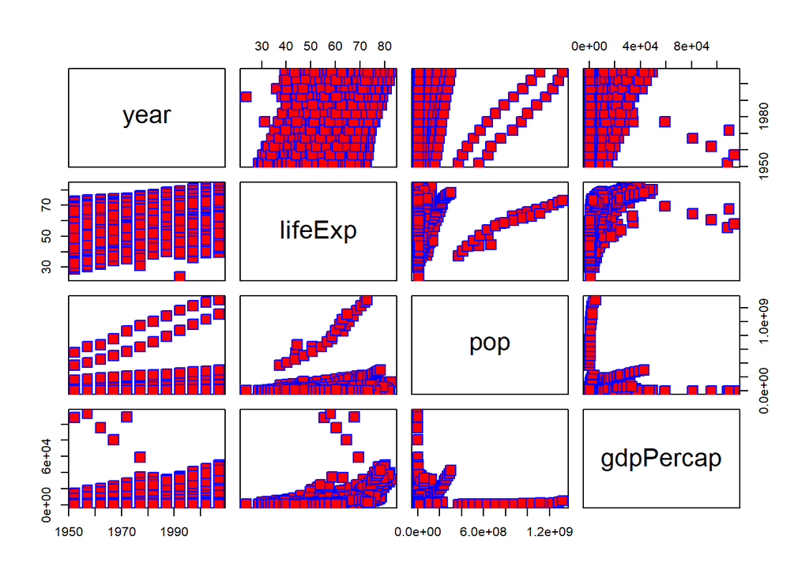

```r
plot(gapminder[,c(3,4,5,6)], col="blue", bg="red", pch=22, cex=2) #cex changes the size
```

- What do the plots tell you?

What if I wanted to create a single scatter plot? In `plot()` try specifying a single variable for **x** and a single variable for **y**. You could add a second set of points to this existing plot using `points()`.

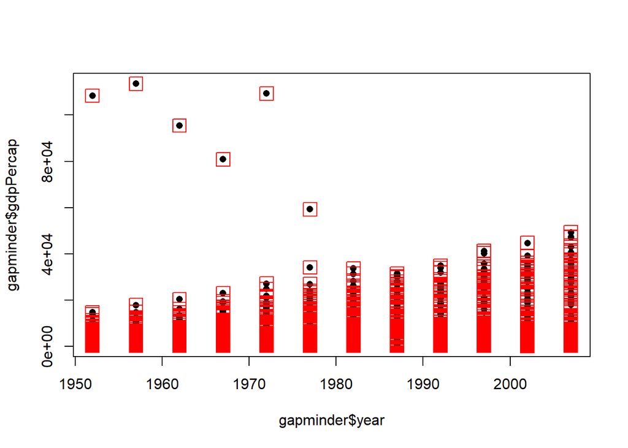

```r
plot(gapminder$year, gapminder$gdpPercap, pch=16)

points(gapminder$year, gapminder$gdpPercap,col="red", pch=0, cex=2)
```

Check out this [source](http://www.sthda.com/english/wiki/r-plot-pch-symbols-the-different-point-shapes-available-in-r) and this [source](https://www.statmethods.net/advgraphs/parameters.html) and `?plot()` for more info on plot options.

Let’s try making some more figures. What it I wanted to examine the distribution of the GDP, life expectancy, and population variables?

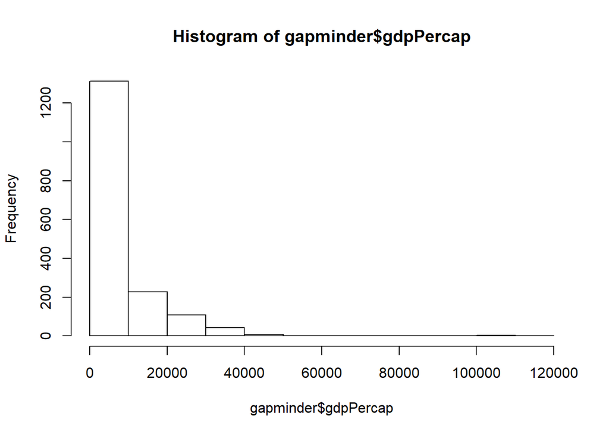

```r
hist(gapminder$gdpPercap)
```

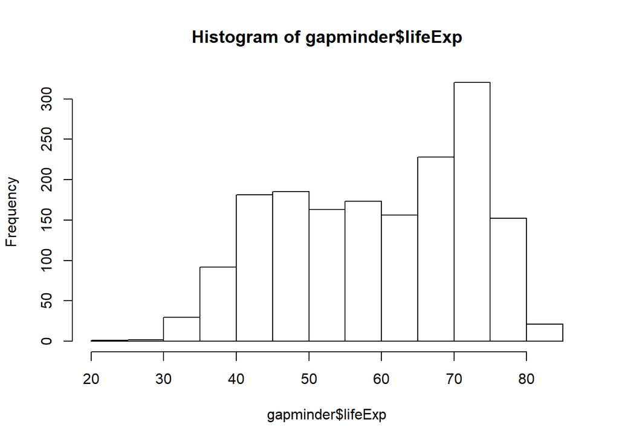

```r
hist(gapminder$lifeExp)
```

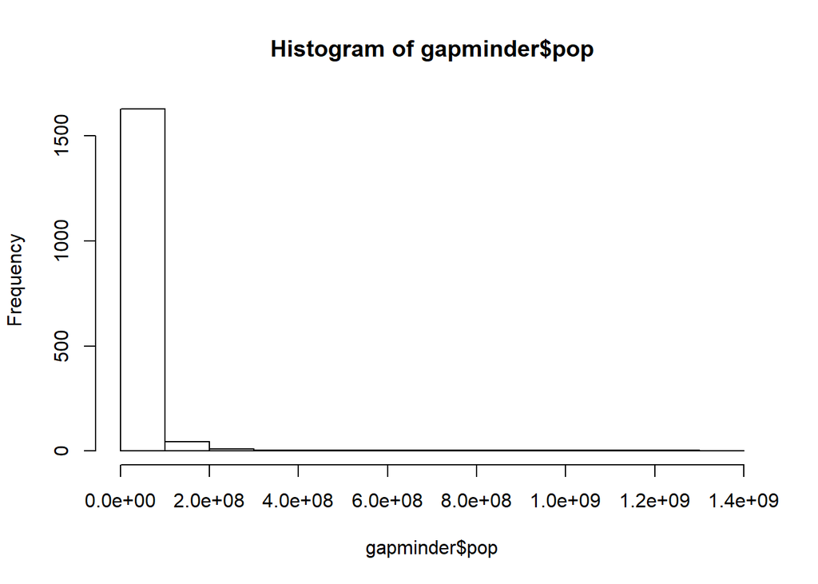

```r
hist(gapminder$pop)
```

Let’s try modifying the histogram settings for the Population variable.

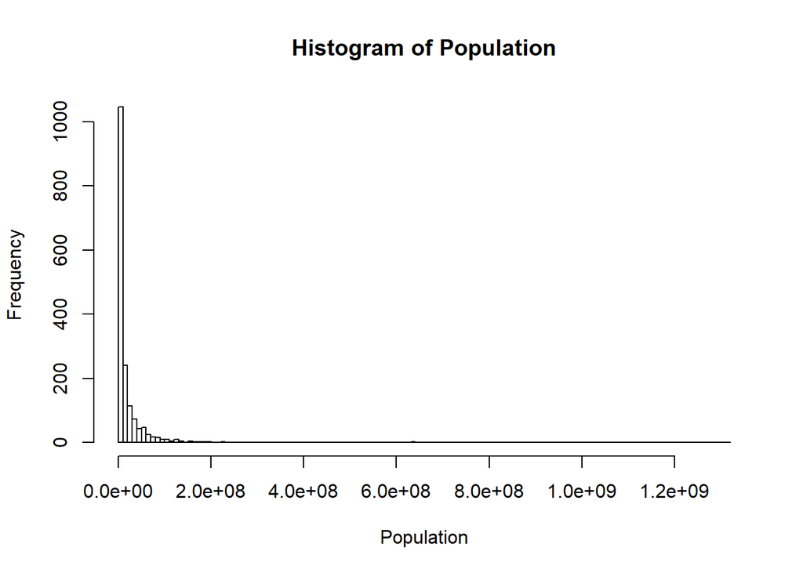

```r
hist(gapminder$pop, breaks = 100, main="Histogram of Population", xlab = "Population", ylab= "Frequency")
```

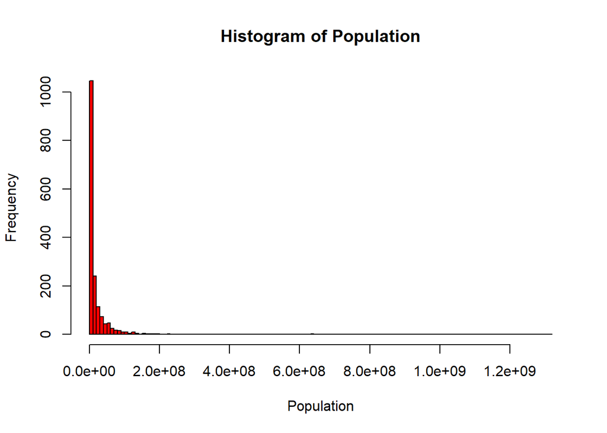

```r
hist(gapminder$pop, breaks = 100, main="Histogram of Population", xlab = "Population", ylab= "Frequency", col="red")
```

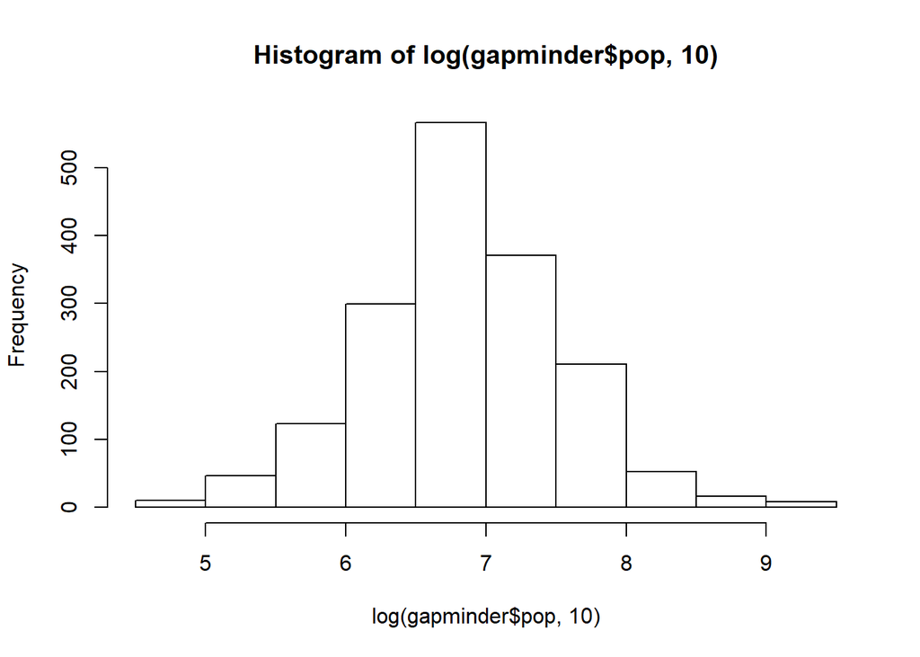

```r
hist(log(gapminder$pop, 10))
```

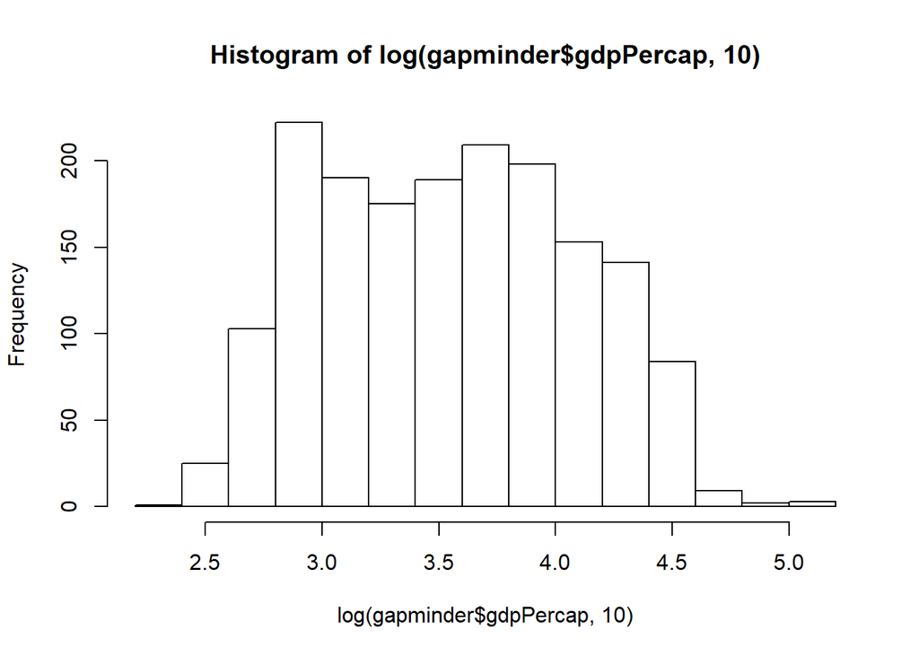

```r
hist(log(gapminder$gdpPercap, 10 ))
```

Well, they certainly look more normal now. (Note that I’m using a log base 10 here.) Hmmmm, so the distribution of GDP and population are a lot more uneven across counties and years (by orders of magnitude) while the distribution of life expectancy is relatively constrained.

Now let’s see how GDP and life expectancy vary across countries and continents.

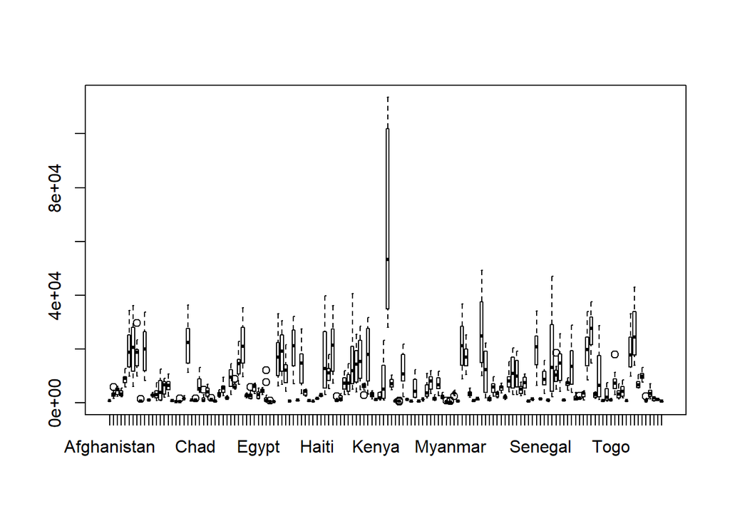

```r
plot(gapminder$country, gapminder$gdpPercap)
```

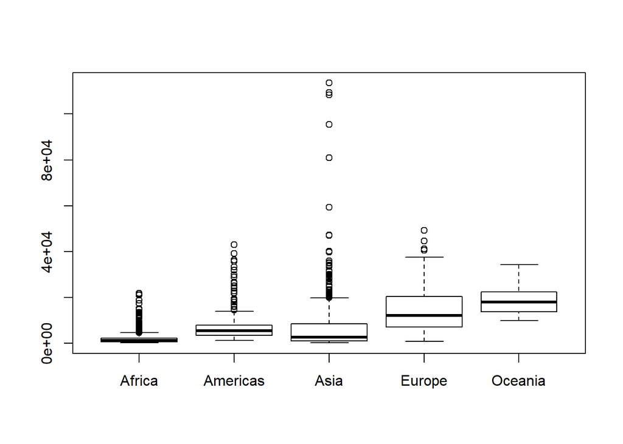

```r
plot(gapminder$continent, gapminder$gdpPercap)
```

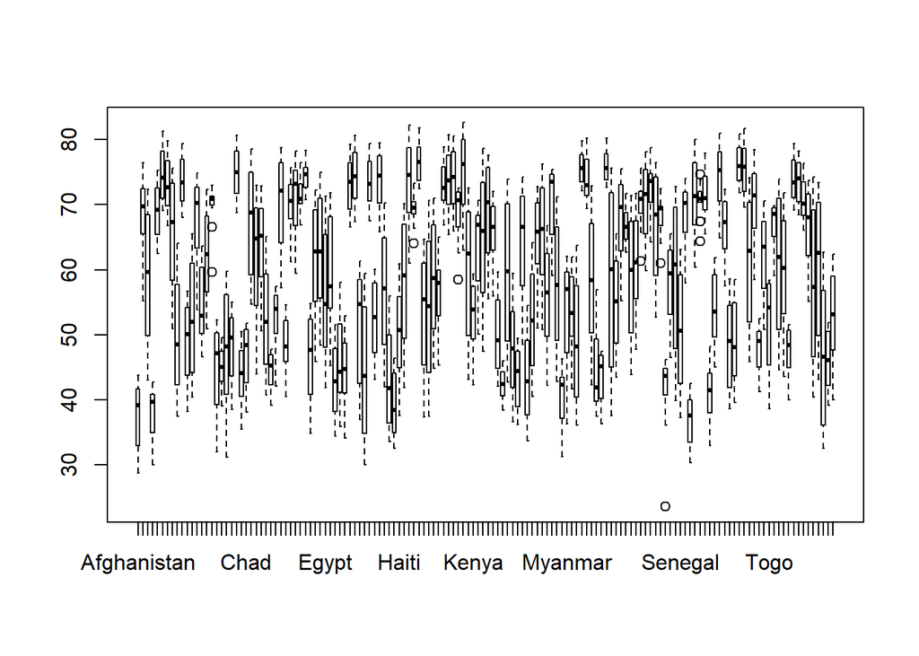

```r
plot(gapminder$country, gapminder$lifeExp)
```

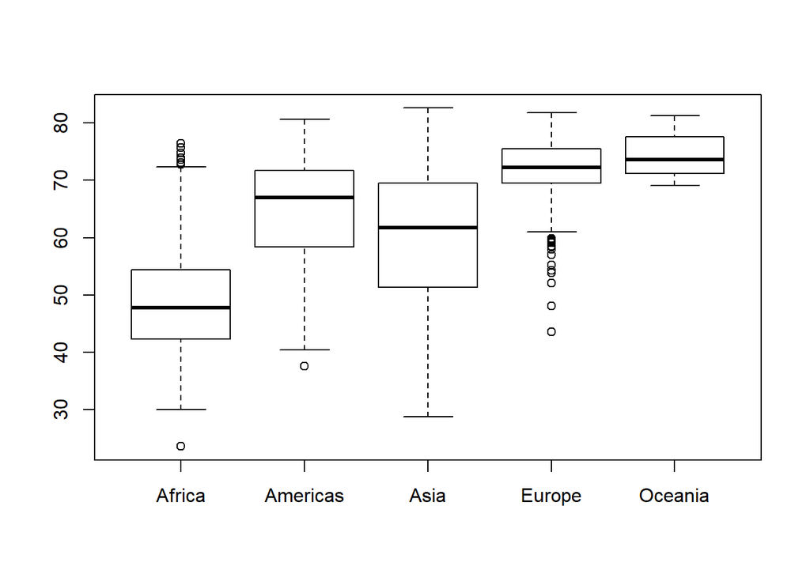

```r
plot(gapminder$continent, gapminder$lifeExp)
```

- What do these plots tell you?

Next week we’ll start looking at `ggplot` which can be used to make some very nice looking plots.

### Lab Assignment

For this lab I’d like you to work a bit more with the `gapminder` data then pull in another dataset from the `datasets` package and play with it a bit too. As before, I would like to see your work in an R Markdown (in both .Rmd and .html) format.

1. For the `gapminder` data order countries in reverse alphabetical order, then display the first 15. This should work out pretty well in this case, but can you think of any potential issues with this process that might lead to ordering problems in a different dataset?
2. Calculate and display the mean, median, and standard deviation for the Life expectancy, Population, and GDPperCapita in the `gapminder` dataset.
3. Calculate and display in a single dataframe the mean values for Life expectancy, Population, and GDPperCapita for each continent.
4. Create a scatter plot of the global average Life expectancy over time and display the first 5 records for the dataset used to build this plot.
5. Pull in a dataset of your choice from the `datasets` package that has a `dataframe` structure. Then examine the structure of the data including: class types, header information, and dimensions.
6. Calculate general summary statistics for a subset of this new dataset as well as summary statistics for groups (these groupings could be bsed on time period, species, location, etc…) within the dataset.
7. Create 2 plots of your choice, one showing grouped data and the other showing ungrouped data. Give each plot a title and descriptive x and y axis labels. Change at least one graphic option (color, point type, line width, etc…) on these plots.